# load packages

```python
import matplotlib.pyplot as plt
import seaborn as sns
import numpy as np
import os.path
sns.set_context("poster")
sns.set_style("whitegrid")
sns.set_palette("Set2")
pal = sns.color_palette()

import pandas as pd

from atomsci.ddm.pipeline import model_pipeline as mp
from atomsci.ddm.pipeline import parameter_parser as parse

pd.set_option('display.max_rows', 10)
pd.set_option('display.max_columns', 200)

nb='02'
mod='RF'
txptr='MRP3'
tcpl='_tcpl'
adj='_adj'
public='' #or _public
valid='_add_valid'
```

# load data and examine

```python
dataset_file = f"/g/g16/apaulson/workspace/datasets/transporters_pIC50{valid}{public}.csv"
```

```python
df = pd.read_csv(dataset_file, index_col=0)
```

```python
print("Duplicate SMILES:",df.duplicated(subset="base_rdkit_smiles").sum())
print("Duplicate compound IDs:",df.duplicated(subset="compound_id").sum())
print("Duplicate indices:",df.index.duplicated().sum())
print("NA SMILES:",df.base_rdkit_smiles.isna().sum())
print("NA meas:", df[f"pIC50_{txptr}{tcpl}{adj}"].isna().sum())
if public=='':cols=['compound_id', f'relation_{txptr}', f'active_{txptr}{tcpl}{adj}', 'Morgan', 'SMDC', 'CRADA', f"pIC50_{txptr}{tcpl}{adj}"]
else: cols=['compound_id', f'relation_{txptr}', f'active_{txptr}{tcpl}{adj}', 'Morgan', 'SMDC',  f"pIC50_{txptr}{tcpl}{adj}"]
meta=df[cols]
df=df[~df[f"pIC50_{txptr}{tcpl}{adj}"].isna()]
print("Pruned data shape:", df.shape)
```

```
Duplicate SMILES: 0
Duplicate compound IDs: 0
Duplicate indices: 0
NA SMILES: 0
NA meas: 524
Pruned data shape: (844, 42)
```

```
Total uncensored values: 844
```

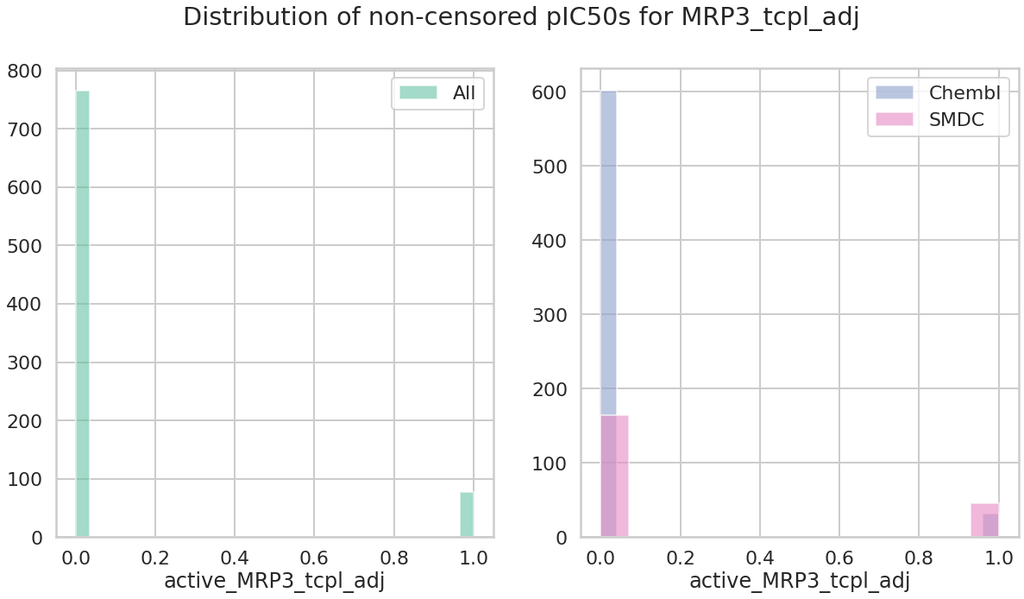

```python
unc = df#[df[f'relation_{txptr}'].isna()]
print("Total uncensored values:", len(unc))

kwargs = dict(kde=False, hist_kws={'alpha':.6})
# bins=np.arange(2,9,0.5)

fig, ax = plt.subplots(1,2, figsize = (20,10))
sns.distplot(unc[f'active_{txptr}{tcpl}{adj}'],                 color = pal[0], label = "All",  **kwargs, ax = ax[0])
ax[0].legend()
sns.distplot(unc[f"active_{txptr}{tcpl}{adj}"][unc["SMDC"]==0], color = pal[2], label="Chembl", **kwargs, ax = ax[1])
sns.distplot(unc[f"active_{txptr}{tcpl}{adj}"][unc["SMDC"]==1], color = pal[3], label="SMDC",   **kwargs, ax = ax[1])

ax[1].legend();
fig.suptitle(f'Distribution of non-censored pIC50s for {txptr}{tcpl}{adj}{public}');
```

# Split and prefeaturize for MOE and Mordred features

- Use this split for the other models too
- The included parameters are required to get the script to run
- For `featurizer = computed descriptors`, precompute! so you don't waste hours of CPU time re-doing it over and over
  - ie `moe`, `mordred_filtered`, `rdkit_raw`, etc
- For larger datasets (>1000 ish compounds) probably do this part in script form not on a login node or in a jupyter notebook - as you can see it takes a long time
- Look here for an example: https://lc.llnl.gov/confluence/display/ATOM/2020/04/22/New+way+to+split+and+featurize+datasets
- **when splitting and featurizing datasets, include ALL response columns you might want, then update later**

```python
params = {
    # general
    "hyperparam": "True",
    "lc_account": "asccasc",
    "slurm_partition": "pbatch",
    #"slurm_time_limit": "720", # for pascal pvis or corona
    "uncertainty": "True",
    "search_type": "user_specified",
    "save_results": "True",
    "verbose": "True",
    #"collection_name": f"DILI_classification{public}",
    "script_dir": "/g/g16/apaulson/github_repos/AMPL/atomsci/ddm",
    "python_path": "/g/g16/apaulson/miniconda3/envs/ampl-120/bin/python",
    "system": "LC",
    "rerun": "False",

    # dataset info
    "use_shortlist": "True",
    "shortlist_key": f"/g/g16/apaulson/workspace/datasets/txptr_shortlist{valid}_with_uuids_scaffold_15_15.csv",
    #"dataset_key" : dataset_key,
    "datastore": "False",
    #"response_cols" : [f"pIC50_{txptr}{tcpl}{adj}", f'active_{txptr}{tcpl}{adj}'],
    #"num_model_tasks" : "2",
    "id_col": "compound_id",
    "smiles_col" : "base_rdkit_smiles",
    "result_dir": f'/g/g16/apaulson/workspace/DILI_Models/txptr_shortlist{valid}{public}_AMPL120',

    # splitting
    "split_only": "True",
    "previously_split": "False",
    "splitter": "scaffold",
    "split_valid_frac": "0.15",
    "split_test_frac": "0.15",

    # featurization & training params
    "prediction_type": "classification",
    "transformers": "True",
    "featurizer": "ecfp,graphconv,computed_descriptors",
    "descriptor_type": "rdkit_raw,moe,mordred_filtered", # for featurizer = computed descriptors
    "model_type": "RF,NN,xgboost",

    #ecfp specific
#     "ecfp_radius":"2,4,6",

    # rf specific
    "rf_estimators": "10,15,20,25,50,100,200,400,800",#"10,15,20,25,30,40,50,60,70,80,90,100,110,120,150,200,300,400,500",#
    "rf_max_depth": "5,10,15,20,50,100",#"5,10,15,20,25,40,60,80,100,120",
    "rf_max_features": "16,20,24,28,32,64",#"16,18,20,22,24,26,28,30,32",

    # nn specific
    'max_epochs': '300',
    "learning_rate": ".00001,.00005,.0001,.0005,.001,.005,.01,.025,.05",
    "layer_sizes": "64,16 64,16 64,16 64,16 128,32 128,32 128,32 128,32 256,64 256,64 256,64 256,64 512,128 512,128 512,128 512,128 256,64,16 256,64,16 256,64,16 256,64,16",
    "dropouts": "0.1,0.1 0.2,0.2 0.3,0.3 0.4,0.4 0.1,0.1 0.2,0.2 0.3,0.3 0.4,0.4 0.1,0.1 0.2,0.2 0.3,0.3 0.4,0.4 0.1,0.1 0.2,0.2 0.3,0.3 0.4,0.4 0.1,0.1,0.1 0.2,0.2,0.2 0.3,0.3,0.3 0.4,0.4,0.4",

    # xgboost specific
    "xgb_gamma": '0.0,0.05,0.1,0.2,0.3,0.4,0.5',
    "xgb_learning_rate": '1,0.5,0.25,0.2,0.15,0.10,0.05,0.01,0.001,0.0001',
}
```

```python
# # # dataset csv file needs to not have an unnamed first column in order to
# # # compute moe descriptors for some reason /shrug
# # # naming it index works, naming it idx messes up the id columns
# # name it manually before running this
# pparams = parse.wrapper(params)
# # MP = mp.ModelPipeline(pparams)

# # # comment out this line after splitting once so you don't re-split
# # split_uuid = MP.split_dataset()
# pparams
```

```python
# split_uuid
# MP.params
```

### set split_uuid here

```python
shortlist = pd.read_csv(f"~/workspace/datasets/txptr_shortlist{valid}_with_uuids_scaffold_15_15.csv")
split_uuid = shortlist.scaffold_15_15[0]
```

```python
split=pd.read_csv(f'/g/g16/apaulson/workspace/datasets/{txptr}{tcpl}{adj}{valid}{public}_train_valid_test_scaffold_{split_uuid}.csv')
split
```

|  | Unnamed: 0 | cmpd_id | fold | subset |
| --- | --- | --- | --- | --- |
| 0 | 0 | 3333 | 0.0 | train |
| 1 | 1 | 5755 | 0.0 | train |
| 2 | 2 | 2726 | 0.0 | train |
| 3 | 3 | 5757 | 0.0 | train |
| 4 | 4 | 3366 | 0.0 | train |
| ... | ... | ... | ... | ... |
| 839 | 11 | SPID254 | 0.0 | train |
| 840 | 12 | SPID319 | 0.0 | train |
| 841 | 13 | SPID385 | 0.0 | train |
| 842 | 14 | SPID229 | 0.0 | train |
| 843 | 15 | SPID459 | 0.0 | train |

844 rows × 4 columns

```python
df = df.merge(split, left_on='compound_id', right_on='cmpd_id')
```

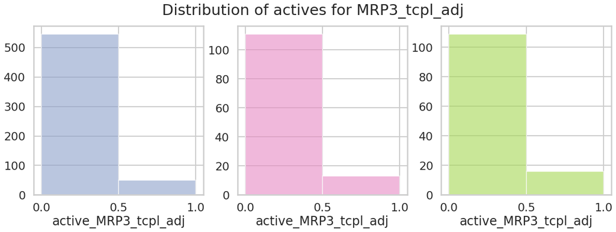

```python
kwargs = dict(kde=False, hist_kws={'alpha':.6})
bins=np.arange(0,1.5,0.5)

fig, ax = plt.subplots(1,3, figsize = (20,6))
sns.distplot(df[f"active_{txptr}{tcpl}{adj}"][df["subset"]=='train'], color = pal[2], bins = bins,  label="train", **kwargs, ax = ax[0])
sns.distplot(df[f"active_{txptr}{tcpl}{adj}"][df["subset"]=='valid'], color = pal[3], bins = bins, label="valid",   **kwargs, ax = ax[1])
sns.distplot(df[f"active_{txptr}{tcpl}{adj}"][df["subset"]=='test'], color = pal[4], bins = bins, label="test",   **kwargs, ax = ax[2])
fig.suptitle(f'Distribution of actives for {txptr}{tcpl}{adj}{public}');
```

```python
cols=['compound_id', 'base_rdkit_smiles']
cols.extend(params['response_cols'])
cols
```

### set feat_type here

```python
import deepchem as dc
from rdkit import Chem
from rdkit.Chem import AllChem

if params["featurizer"]=="computed_descriptors":
    feat_type=params["descriptor_type"]
    feat=pd.read_csv(f'/g/g16/apaulson/workspace/datasets/scaled_descriptors/{txptr}{tcpl}{adj}{public}_with_{feat_type}_descriptors.csv')
    print(feat.shape)
    feat_noNA = feat.dropna(axis = "columns")
    #if feat_type == 'rdkit_raw':
    #    feat_noNA = feat_noNA.drop(columns='Ipc')
    print(feat_noNA.shape)
elif params["featurizer"]=="ecfp":
    feat_type=params['featurizer']
    mols = [Chem.MolFromSmiles(s) for s in df["base_rdkit_smiles"]]
    feat = [AllChem.GetMorganFingerprintAsBitVect(mol, 2, 1024) for mol in mols]
    feat = pd.DataFrame(np.array(feat, dtype=int))
    feat = df[cols].join(pd.DataFrame(feat).add_prefix("ecfp2_"))
    print(feat.shape)
    feat_noNA = feat.dropna(axis = "columns")
    print(feat.shape)
elif params["featurizer"]=="graphconv":
    feat_type=params['featurizer']
    print("Can't do graphconv UMAP")
    feat=df
    feat_noNA=df
else: feat_type=params['featurizer'].replace(',','-')
```

```python
if 'feat_noNA' in locals():
    umap_df=feat_noNA.merge(split, left_on="compound_id", right_on="cmpd_id")
    umap_df.compound_id=umap_df.compound_id.astype(str)
    print(umap_df.shape)
    umap_df=umap_df.merge(df, on=['compound_id', 'base_rdkit_smiles'], suffixes=["", "_orig"])
    print(umap_df.shape)
```

# UMAP of compound train/test/split from features

```python
dataset_name = f'{params["collection_name"]}'
labelcol="subset"
valuecol = params["response_cols"][0]
if public=='':labelcols = ["subset", valuecol, f"relation_{txptr}", f'active_{txptr}{tcpl}{adj}', "compound_id", "Morgan", "SMDC", "CRADA"]
else: labelcols = ["subset", valuecol, f"relation_{txptr}", f'active_{txptr}{tcpl}{adj}', "compound_id", "Morgan", "SMDC"]
print(dataset_name, cols[-1])
```

### set dataset_name here

```python
import umap
# assign columns
plot_df = umap_df       # plot with whole df
map_df = plot_df.loc[:,feat_noNA.columns[4:]] # umap on feat values only
```

```python
# run the rest of the plotting code without changing anything
mapper = umap.UMAP(n_neighbors=15, n_components=2, metric='jaccard').fit(map_df)
```

```python
umap_coords = pd.DataFrame(mapper.embedding_, columns=("UMAP_X", "UMAP_Y"))
umap_coords = umap_coords.join(plot_df[labelcols])
cat_type = pd.api.types.CategoricalDtype(categories=["train", "valid", "test"],ordered=True)
umap_coords[labelcol]=umap_coords[labelcol].astype(cat_type)
umap_coords.shape
```

```
(728, 9)
```

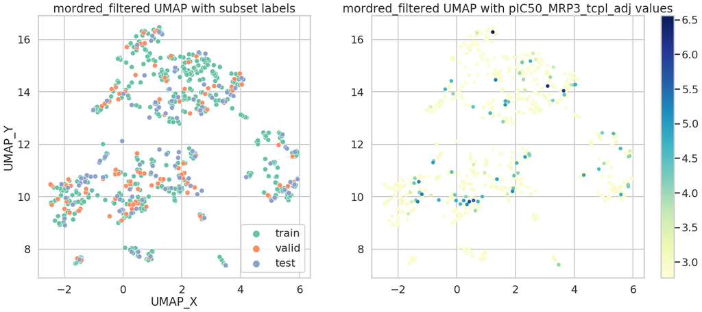

```python
fig, (ax1, ax2) = plt.subplots(1,2, figsize=(25,10), gridspec_kw={'width_ratios': [8, 10]})

# train/val/test labels
umap_coords = umap_coords.sort_values(labelcol)                   # this might screw up merging or something later! it allows viz to look better
sns.scatterplot(x=umap_coords["UMAP_X"], y=umap_coords["UMAP_Y"],
                hue=labelcol, data=umap_coords, s=100, ax=ax1)
handles, labels = ax1.get_legend_handles_labels()
#ax1.set_facecolor('lightgray')
ax1.legend(handles=handles[1:], loc="lower right")
ax1.title.set_text(f"{feat_type} UMAP with {labelcol} labels")

umap_coords = umap_coords.sort_values(valuecol)
# pIC50 value labels
sclab2=ax2.scatter(umap_coords["UMAP_X"], umap_coords["UMAP_Y"],
            s=30, c=umap_coords[valuecol],  cmap="YlGnBu", )
#ax2.set_facecolor('lightgray')
ax2.title.set_text(f"{feat_type} UMAP with {valuecol} values")

# color bar properties
plt.colorbar(sclab2, ax = ax2);

# plt.savefig(f"/g/g16/apaulson/workspace/{txptr}_comb_modeling/plots/{nb}_UMAP_{dataset_name}_{feat_type}_{split_num}.png", dpi=300)
```

# Create parameter json

Parameter options here: https://github.com/ATOMScience-org/AMPL/blob/master/atomsci/ddm/docs/PARAMETERS.md

- get split_uuid from csv file ^
- get `lc_account` from `$ mshare` on machine you want to run your modeling from

```python
import json
```

### set other naming params here

```python
params['split_only'] = 'False'
#params['split_uuid'] = split_uuid
params['previously_split'] = 'True'

#params['num_model_tasks']='1'
#params['response_cols']=cols[-1]

pred_type=params["prediction_type"]
split_type=params["splitter"]
model_type=params["model_type"]

if params['model_type']=='xgboost':
    params['uncertainty']='False'

params['slurm_partition']='pbatch'
if params['slurm_partition']=='pvis':
    params['max_jobs']='8'
    params["slurm_time_limit"]="720"
elif params['slurm_partition']=='pbatch':
    params['max_jobs']='80'
    params["slurm_time_limit"]="1440"
params['rerun']='False'
```

```python
params
```

```
{'hyperparam': 'True',
 'lc_account': 'asccasc',
 'slurm_partition': 'pbatch',
 'uncertainty': 'True',
 'search_type': 'user_specified',
 'save_results': 'True',
 'verbose': 'True',
 'script_dir': '/g/g16/apaulson/github_repos/AMPL/atomsci/ddm',
 'python_path': '/g/g16/apaulson/miniconda3/envs/ampl-120/bin/python',
 'system': 'LC',
 'rerun': 'False',
 'use_shortlist': 'True',
 'shortlist_key': '/g/g16/apaulson/workspace/datasets/txptr_shortlist_add_valid_with_uuids_scaffold_15_15.csv',
 'datastore': 'False',
 'id_col': 'compound_id',
 'smiles_col': 'base_rdkit_smiles',
 'result_dir': '/g/g16/apaulson/workspace/DILI_Models/txptr_shortlist_add_valid_AMPL120',
 'split_only': 'False',
 'previously_split': 'True',
 'splitter': 'scaffold',
 'split_valid_frac': '0.15',
 'split_test_frac': '0.15',
 'prediction_type': 'classification',
 'transformers': 'True',
 'featurizer': 'ecfp,graphconv,computed_descriptors',
 'descriptor_type': 'rdkit_raw,moe,mordred_filtered',
 'model_type': 'RF,NN,xgboost',
 'rf_estimators': '10,15,20,25,50,100,200,400,800',
 'rf_max_depth': '5,10,15,20,50,100',
 'rf_max_features': '16,20,24,28,32,64',
 'max_epochs': '300',
 'learning_rate': '.00001,.00005,.0001,.0005,.001,.005,.01,.025,.05',
 'layer_sizes': '64,16 64,16 64,16 64,16 128,32 128,32 128,32 128,32 256,64 256,64 256,64 256,64 512,128 512,128 512,128 512,128 256,64,16 256,64,16 256,64,16 256,64,16',
 'dropouts': '0.1,0.1 0.2,0.2 0.3,0.3 0.4,0.4 0.1,0.1 0.2,0.2 0.3,0.3 0.4,0.4 0.1,0.1 0.2,0.2 0.3,0.3 0.4,0.4 0.1,0.1 0.2,0.2 0.3,0.3 0.4,0.4 0.1,0.1,0.1 0.2,0.2,0.2 0.3,0.3,0.3 0.4,0.4,0.4',
 'xgb_gamma': '0.0,0.05,0.1,0.2,0.3,0.4,0.5',
 'xgb_learning_rate': '1,0.5,0.25,0.2,0.15,0.10,0.05,0.01,0.001,0.0001',
 'max_jobs': '80',
 'slurm_time_limit': '1440'}
```

```python
fname=f'/g/g16/apaulson/workspace/scripts/DILI_shortlist{public}_{nb}_{pred_type}_{split_type}_03_{feat_type}_RF-NN-XG_hyper_config_AMPL120.json'
with open(fname, 'w') as fp:
    json.dump(params, fp, indent=4)

print(f'python ~/github_repos/AMPL/atomsci/ddm/utils/hyperparam_search_wrapper.py --config_file {fname}')
```

```
python ~/github_repos/AMPL/atomsci/ddm/utils/hyperparam_search_wrapper.py --config_file /g/g16/apaulson/workspace/scripts/DILI_shortlist_02_classification_scaffold_03_ecfp-graphconv-computed_descriptors_RF-NN-XG_hyper_config_AMPL120.json
```

# Train models

- use `tmux` so if you disconnect from ssh it doesn't kill the jobs
- run the following from an environment with AMPL installation:

`$ cd ~`

`$ ulimit -n 2048` (optional if you will submit >1024 models)

`$ conda activate atom/programs/atomsci_conda/atomsci`

^^copy/paste the printout there

- monitor the jobs with `squeue` (optional: `-u apaulson`)
- monitor results with: `tail -qn 2 /g/g16/apaulson/workspace/MRP3_comb_modeling/slurm_files/*`

# examine results

```python
from atomsci.ddm.pipeline import compare_models as cmp
import numpy as np
from pandas.api.types import CategoricalDtype
sns.set_context('poster')
sns.set_style('white')
```

```python
pred_type='classification'
```

```python
shortlist
```

|  | Unnamed: 0 | bucket_name | dataset_key | response_cols | collection | scaffold_15_15 |
| --- | --- | --- | --- | --- | --- | --- |
| 0 | 0 | public | /g/g16/apaulson/workspace/datasets/MRP3_tcpl_a... | active_MRP3_tcpl_adj | DILI_txptr_class_120_add_valid | f88e002c-d6b7-4733-906b-c696ccdf9895 |
| 1 | 1 | public | /g/g16/apaulson/workspace/datasets/MRP4_tcpl_a... | active_MRP4_tcpl_adj | DILI_txptr_class_120_add_valid | ce8ca858-196d-46cc-b412-ddd8d25ba8b8 |
| 2 | 2 | public | /g/g16/apaulson/workspace/datasets/MRP3_tcpl_a... | active_MRP3_tcpl_adj | DILI_txptr_class_120_public_add_valid | c4682727-9512-4f54-86e0-827258239707 |
| 3 | 3 | public | /g/g16/apaulson/workspace/datasets/MRP4_tcpl_a... | active_MRP4_tcpl_adj | DILI_txptr_class_120_public_add_valid | f2f13a9f-c10e-4137-998b-3c791a7a4831 |

```python
slidx=0

# allmodels  = cmp.get_multitask_perf_from_tracker(shortlist.collection[slidx], response_cols=shortlist.response_cols[slidx], exhaustive=True)
# allmodels  = cmp.get_multitask_perf_from_tracker(shortlist.collection[slidx], response_cols=None, exhaustive=True)

# allmodels2 = cmp.get_multitask_perf_from_tracker(shortlist.collection[1], response_cols=shortlist.response_cols[1], exhaustive=True)
# allmodels  = allmodels.merge(allmodels2)

# allmodels2 = cmp.get_multitask_perf_from_tracker(shortlist.collection[2], response_cols=shortlist.response_cols[2], exhaustive=True)
# allmodels  = allmodels.merge(allmodels2)

# allmodels2 = cmp.get_multitask_perf_from_tracker(shortlist.collection[3], response_cols=shortlist.response_cols[3], exhaustive=True)
# allmodels  = allmodels.merge(allmodels2)

# allmodels2 = cmp.get_multitask_perf_from_tracker(shortlist.collection[4], response_cols=shortlist.response_cols[4], exhaustive=True)
# allmodels  = allmodels.merge(allmodels2)

collections=['DILI_txptr_class_120_add_valid']
responsecols = 'active_MRP3_tcpl_adj'
allmodels3=cmp.get_multitask_perf_from_tracker(collections[0], response_cols=responsecols,
                                              expand_subsets='train,test,val', exhaustive=True)
allmodels3#=allmodels3[(~allmodels3.features.str.contains('scr'))&(~allmodels3.features.str.contains('txptr'))]
allmodels3#['model_run']='No bio data'
allmodels3#=allmodels3.reset_index(drop=True)
print(allmodels3.best_valid_roc_auc_score.max())
print(allmodels3.shape)
display(allmodels3[['model_type', 'features', 'best_valid_roc_auc_score']].groupby(by=['model_type', 'features']).max().T)
display(allmodels3[['model_type', 'features', 'best_valid_roc_auc_score']].groupby(by=['model_type', 'features']).count().T)
allmodels=allmodels3
print(allmodels.shape)
print(allmodels.model_type.unique())
print(allmodels.model_type.value_counts())
```

```
Response cols: ['active_MRP3_tcpl_adj']
0.9251559251559252
(2150, 98)
```

| model_type features | NN ecfp | RF ecfp | RF moe | RF mordred_filtered | RF rdkit_raw |
| --- | --- | --- | --- | --- | --- |
| best_valid_roc_auc_score | 0.836452 | 0.830561 | 0.892238 | 0.918919 | 0.925156 |

| model_type features | NN ecfp | RF ecfp | RF moe | RF mordred_filtered | RF rdkit_raw |
| --- | --- | --- | --- | --- | --- |
| best_valid_roc_auc_score | 165 | 324 | 648 | 365 | 648 |

```
(2150, 98)
['RF' 'NN']
RF    1985
NN     165
Name: model_type, dtype: int64
```

```python
print("RF mods", 4*9*6*6)
print("NN mods", 5*9*5*4)
print("XG mods", 4*7*10)
```

```
RF mods 1296
NN mods 900
XG mods 280
```

```python
allmodels.dataset_key.unique()
```

```
array(['/g/g16/apaulson/workspace/datasets/MRP3_tcpl_adj_add_valid.csv'],
      dtype=object)
```

```python
allmodels[(allmodels.features=='moe') & (allmodels.split_valid_frac==.15) & (allmodels.model_type=='RF') &
          (allmodels.rf_estimators==10) &
          (allmodels.rf_max_depth==5) & (allmodels.rf_max_features==28)]
```

|  | model_uuid | time_built | ecfp_radius | ecfp_size | ampl_version | featurizer | hyperparam_uuid | model_bucket | model_choice_score_type | model_dataset_oid | model_type | num_model_tasks | prediction_type | save_results | system | time_generated | transformer_bucket | transformer_key | transformer_oid | transformers | uncertainty | rf_estimators | rf_max_depth | rf_max_features | base_splitter | butina_cutoff | cutoff_date | date_col | num_folds | … |
| --- | --- | --- | --- | --- | --- | --- | --- | --- | --- | --- | --- | --- | --- | --- | --- | --- | --- | --- | --- | --- | --- | --- | --- | --- | --- | --- | --- | --- | --- | --- |
| 650 | d8d30a80-4fa4-436b-9467-d3099d03c566 | 1.642221e+09 | NaN | NaN | 1.2.2 | computed_descriptors | None | public | roc_auc | 61e24d008c9a80b949f2e61d | RF | 1.0 | classification | 1.0 | LC | 1.642221e+09 |  | /g/g16/apaulson/workspace/DILI_Models/txptr_sh... |  | 1.0 | 1.0 | 10.0 | 5.0 | 28.0 | scaffold | 0.6 | None | None | 5.0 | … |
| 1340 | 9840e10a-656b-4497-ae83-8ed440059e52 | 1.642450e+09 | NaN | NaN | 1.2.2 | computed_descriptors | None | public | roc_auc | 61e5cdbd06ed0b83b1f2e830 | RF | 1.0 | classification | 1.0 | LC | 1.642450e+09 |  | /g/g16/apaulson/workspace/DILI_Models/txptr_sh... |  | 1.0 | 1.0 | 10.0 | 5.0 | 28.0 | scaffold | 0.6 | None | None | 5.0 | … |

```python
allmodels.features.unique()
```

```
array(['ecfp', 'rdkit_raw', 'moe', 'mordred_filtered'], dtype=object)
```

```python
scoretype = 'roc_auc_score'
winnertype= f'best_valid_{scoretype}'
perf_track_df=allmodels.sort_values(by=winnertype, ascending=False)#[(allmodels.features.isin(feat_type))] # &
#                                                                   (allmodels.model_type==model_type) &
#                                                                   (allmodels.split_uuid==split_uuid) &
#                                                                   (allmodels.parameter==pred_param) &
#                                                                   (allmodels.train_r2_score>-5)]
print(perf_track_df.shape)
print('top roc auc score:', perf_track_df[f'{winnertype}'].max().round(4))
if (sum(~perf_track_df.dropouts.isna())>0):
    perf_track_df['plot_dropout'] = perf_track_df.dropouts.astype(str).str.strip('[]').str.split(pat=',',n=1, expand=True)[0]
    perf_track_df['plot_dropout'] = perf_track_df['plot_dropout'].astype(float)
    perf_track_df['layer_sizes'] = perf_track_df.layer_sizes.astype(str).str.strip('[]')
    perf_track_df[['dummy_nodes_1','dummy_nodes_2','dummy_nodes_3']]=perf_track_df.layer_sizes.str.split(pat=',', n=3, expand=True).astype(float)
    perf_track_df['num_layers'] = 3-perf_track_df[['dummy_nodes_1','dummy_nodes_2','dummy_nodes_3']].isna().sum(axis=1)
    perf_track_df[['dummy_nodes_1','dummy_nodes_2','dummy_nodes_3']]=perf_track_df[['dummy_nodes_1','dummy_nodes_2','dummy_nodes_3']].fillna(value=1).astype(int)
    perf_track_df['num_nodes']=perf_track_df.dummy_nodes_1 * perf_track_df.dummy_nodes_2 * perf_track_df.dummy_nodes_3
    perf_track_df=perf_track_df.drop(columns=['dummy_nodes_1','dummy_nodes_2','dummy_nodes_3'])
    perf_track_df.loc[perf_track_df.model_type != "NN", 'layer_sizes']=np.nan
    perf_track_df.loc[perf_track_df.model_type != "NN", 'num_layers']=np.nan
    perf_track_df.loc[perf_track_df.model_type != "NN", 'num_nodes']=np.nan
    perf_track_df.loc[perf_track_df.model_type != "NN", 'plot_dropout']=np.nan
```

[output not shown]

```python
perf_track_df['layer_sizes'].unique()
```

```
array([nan, '256, 64', '512, 128', '256, 64, 16', '128, 32', '64, 16'],
      dtype=object)
```

```python
estcat = CategoricalDtype(categories=[10,15,20,25,50,100,200,400,800], ordered=True)
featcat = CategoricalDtype(categories=[16,20,24,28,32,64], ordered=True)
depthcat = CategoricalDtype(categories=[5,10,15,20,50,100], ordered=True)
perf_track_df["rf_max_features"] = perf_track_df["rf_max_features"].astype(featcat)
perf_track_df["rf_estimators"] = perf_track_df["rf_estimators"].astype(estcat)
perf_track_df["rf_max_depth"] = perf_track_df["rf_max_depth"].astype(depthcat)

dropcat = CategoricalDtype(categories=[0.1, 0.2, 0.3, 0.4], ordered=True)
perf_track_df["plot_dropout"] = perf_track_df["plot_dropout"].astype(dropcat)
learncat = CategoricalDtype(categories=[.00001,.00005,.0001,.0005,.001,.005,.01,.025,.05], ordered=True)
perf_track_df["learning_rate"] = perf_track_df["learning_rate"].astype(learncat)
layercat = CategoricalDtype(categories=['64, 16', '128, 32', '256, 64', '512, 128', '256, 64, 16'], ordered=True)
perf_track_df["layer_sizes"] = perf_track_df["layer_sizes"].astype(layercat)
```

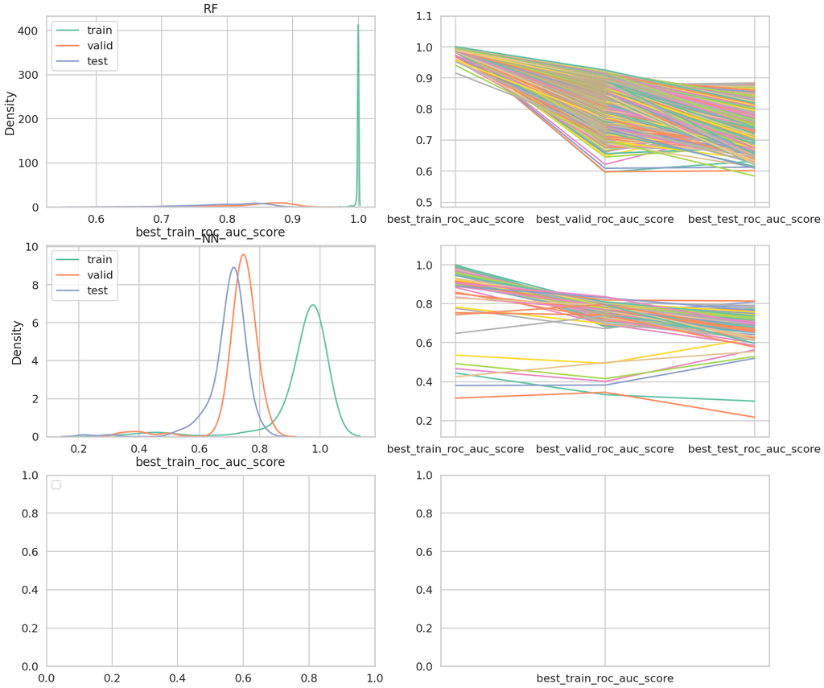

```python
scoretype='roc_auc_score'
subset='valid'
winnertype= f'best_{subset}_{scoretype}'

perf_track_df=perf_track_df[perf_track_df[winnertype]>0]

fig, ax = plt.subplots(3,2,figsize=(26,24))
ax=ax.ravel()
i=0
for modtype in ["RF", "NN", "xgboost"]:
    kdeplotdf=perf_track_df[perf_track_df.model_type==modtype]
    sns.kdeplot(kdeplotdf[f'best_train_{scoretype}'], label="train",ax=ax[i])
    sns.kdeplot(kdeplotdf[f'best_valid_{scoretype}'], label="valid",ax=ax[i])
    sns.kdeplot(kdeplotdf[f'best_test_{scoretype}'], label="test",  ax=ax[i])
    ax[i].legend(loc="upper left")
    plot_df=kdeplotdf[[f"best_train_{scoretype}",f"best_valid_{scoretype}",f"best_test_{scoretype}"]].sort_values(winnertype)
    ax[i+1].plot(plot_df.T);
    ax[i+1].set_ylim(plot_df.min().min()-.1,1.1)
    ax[i].set_title(modtype)
    i+=2
plt.tight_layout()
```

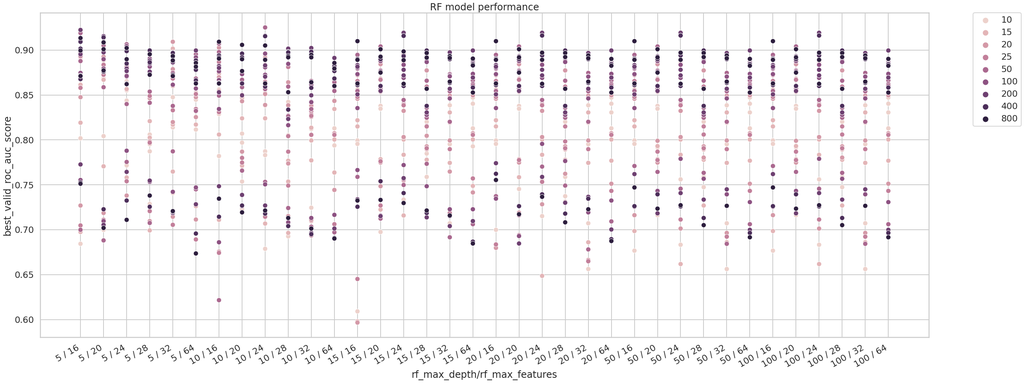

```python
if sum(~perf_track_df.rf_estimators.isna())>0:
    feat3 = 'rf_estimators'; feat1 = 'rf_max_depth'; feat2 = 'rf_max_features'
    hue=feat3
    plot_df=perf_track_df[perf_track_df.model_type=='RF']
    plot_df = plot_df.sort_values([feat3, feat1, feat2])
    plot_df[f'{feat1}/{feat2}'] = ['%s / %s' % (mf,est) for mf,est in zip(plot_df[feat1], plot_df[feat2])]
    with sns.axes_style("whitegrid"):
        fig = plt.figure(figsize=(40,15))
        ax1 = fig.add_subplot(111)
        sns.scatterplot(x=f'{feat1}/{feat2}', y='best_{0}_{1}'.format(subset, scoretype), hue=hue, palette=sns.cubehelix_palette(len(plot_df[hue].unique())), data=plot_df, ax=ax1)
        plt.legend(bbox_to_anchor=(1.05, 1), loc=2, borderaxespad=0.)
        plt.xticks(rotation=30, ha='right')
        plt.title(f'RF model performance');
```

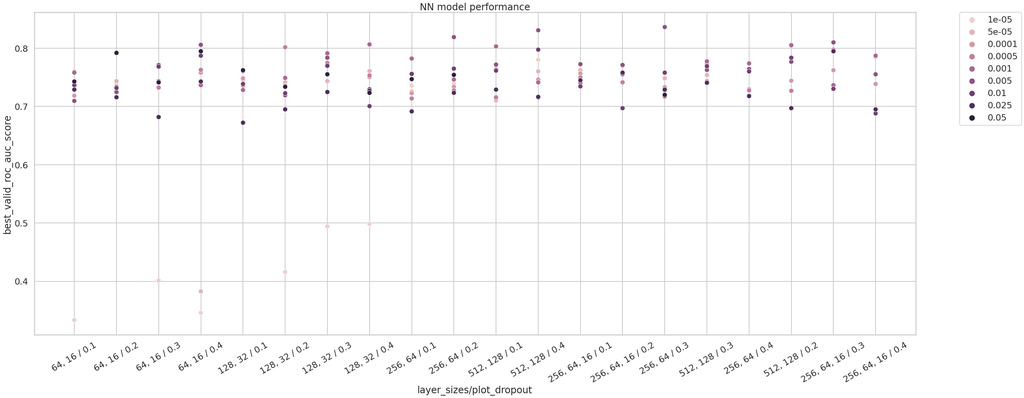

```python
if sum(~perf_track_df.plot_dropout.isna())>0:
    feat3 = 'learning_rate'; feat2 = 'plot_dropout'; feat1 = 'layer_sizes'
    hue=feat3
    plot_df=perf_track_df[perf_track_df.model_type=='NN']
    plot_df = plot_df.sort_values([feat3, feat1, feat2])
    plot_df[f'{feat1}/{feat2}'] = ['%s / %s' % (mf,est) for mf,est in zip(plot_df[feat1], plot_df[feat2])]
    with sns.axes_style("whitegrid"):
        fig = plt.figure(figsize=(40,15))
        ax1 = fig.add_subplot(111)
        sns.scatterplot(x=f'{feat1}/{feat2}', y='best_{0}_{1}'.format(subset, scoretype), hue=hue, palette=sns.cubehelix_palette(len(plot_df[hue].unique())), data=plot_df, ax=ax1)
        plt.legend(bbox_to_anchor=(1.05, 1), loc=2, borderaxespad=0.)
        plt.xticks(rotation=30, ha='center')
        plt.title(f'NN model performance');
```

[figure not shown]

```python
if sum(~perf_track_df.xgb_gamma.isna())>0:
    feat2 = 'xgb_learning_rate'; feat1 = 'xgb_gamma'
    hue=feat2
    plot_df=perf_track_df[perf_track_df.model_type=='xgboost']
    plot_df = plot_df.sort_values([feat1, feat2])
    #plot_df[f'{feat1}/{feat2}'] = ['%s / %s' % (mf,est) for mf,est in zip(plot_df[feat1], plot_df[feat2])]
    with sns.axes_style("whitegrid"):
        fig = plt.figure(figsize=(40,15))
        ax1 = fig.add_subplot(111)
        sns.scatterplot(x=feat1, y='best_{0}_{1}'.format(subset, scoretype),
                        hue=hue, palette=sns.cubehelix_palette(len(plot_df[hue].unique())),
                        data=plot_df, ax=ax1)
        plt.legend(bbox_to_anchor=(1.05, 1), loc=2, borderaxespad=0.)
        plt.xticks(rotation=30, ha='center')
        plt.title(f'XGboost model performance');
```

```python
nfeats=3; scoretype='roc_auc'; winnertype='best_valid_roc_auc_score'
feat1='plot_dropout'; feat2='learning_rate'; feat3='num_nodes'
feat4='layer_sizes'; feat5='rf_max_depth'; feat6='rf_max_features'
feat7='rf_estimators'; feat8='xgb_gamma'; feat9='xgb_learning_rate'
feat10='features'; feat11='model_type'; feat12='best_test_roc_auc_score'
```

[figure not shown]

```python
sns.set_context('poster')
plotdf2=perf_track_df
fig, ax = plt.subplots(4,3, figsize=(32,24))
if sum(~perf_track_df.dropouts.isna())>0:
    sns.boxplot(x=feat1, y=winnertype, palette=sns.cubehelix_palette(len(plotdf2[feat1].unique()), rot=0, start=0.40), data=plotdf2,    ax=ax[0,0]); ax[0,0].tick_params(rotation=0);  ax[0,0].set_xlabel('NN dropouts')
    sns.boxplot(x=feat2, y=winnertype, palette=sns.cubehelix_palette(len(plotdf2[feat2].unique()), rot=0, start=0.40), data=plotdf2,    ax=ax[0,1]); ax[0,1].tick_params(rotation=30); ax[0,1].set_xlabel('NN learning rate')#ax[0,1].legend_.remove(); ax[0,1].title.set_text(f"Hyperparameters colored by {feat1}")
    plotdf=perf_track_df[perf_track_df[feat3]>0]
    sns.boxplot(x=feat3, y=winnertype, palette=sns.cubehelix_palette(len(plotdf[feat3].unique()), rot=0, start=0.40), data=plotdf,    ax=ax[0,2]); ax[0,2].tick_params(rotation=60); ax[0,2].set_xlabel('NN number of parameters in hidden layers')#ax[0,2].legend_.remove()#(bbox_to_anchor=(1,1), title=feat1)#, prop={'size': 12})
    sns.boxplot(x=feat4, y=winnertype, palette=sns.cubehelix_palette(len(plotdf2[feat4].unique()), rot=0, start=0.40), data=plotdf2,    ax=ax[1,0]); ax[1,0].tick_params(rotation=0);  ax[1,0].set_xlabel('NN layer sizes')#ax[1,0].legend_.remove(); ax[1,0].tick_params(rotation=45)
if sum(~perf_track_df.xgb_gamma.isna())>0:
    sns.boxplot(x=feat8, y=winnertype, palette=sns.cubehelix_palette(len(plotdf2[feat8].unique()), rot=0, start=2.75), data=plotdf2,    ax=ax[1,1]); ax[1,1].tick_params(rotation=0);  ax[1,1].set_xlabel('XGBoost gamma')#ax[1,1].title.set_text(f"Hyperparameters colored by {feat2}")
    sns.boxplot(x=feat9, y=winnertype, palette=sns.cubehelix_palette(len(plotdf2[feat9].unique()), rot=0, start=2.75), data=plotdf2,    ax=ax[1,2]); ax[1,2].tick_params(rotation=0);  ax[1,2].set_xlabel('XGBoost learning rate')#ax[1,2].legend_.remove()#(bbox_to_anchor=(1,1), title=feat2)
if sum(~perf_track_df.rf_estimators.isna())>0:
    sns.boxplot(x=plotdf2.loc[~plotdf2[feat7].isna(),feat7].astype(int), y=winnertype, palette=sns.cubehelix_palette(len(plotdf2[feat7].unique()), rot=0, start=2.00), data=plotdf2,    ax=ax[2,0]); ax[2,0].tick_params(rotation=45); ax[2,0].set_xlabel('RF number of trees')#ax[2,0].legend_.remove(); ax[2,0].tick_params(rotation=45)
    sns.boxplot(x=plotdf2.loc[~plotdf2[feat5].isna(),feat5].astype(int), y=winnertype, palette=sns.cubehelix_palette(len(plotdf2[feat5].unique()), rot=0, start=2.00), data=plotdf2,    ax=ax[2,1]); ax[2,1].tick_params(rotation=0); ax[2,1].set_xlabel('RF max depth')#ax[2,1].legend_.remove(); ax[2,1].title.set_text(f"Hyperparameters colored by {feat3}")
    sns.boxplot(x=plotdf2.loc[~plotdf2[feat6].isna(),feat6].astype(int), y=winnertype, palette=sns.cubehelix_palette(len(plotdf2[feat6].unique()), rot=0, start=2.00), data=plotdf2,    ax=ax[2,2]); ax[2,2].tick_params(rotation=0); ax[2,2].set_xlabel('RF max features per node')#ax[2,2].legend(bbox_to_anchor=(1,1), title=feat3);
#general
sns.boxplot(x=feat10, y=winnertype, palette=sns.cubehelix_palette(len(plotdf2[feat10].unique()), rot=0, start=0.20), data=plotdf2,  ax=ax[3,0]); ax[3,0].tick_params(rotation=0);  ax[3,0].set_xlabel('Featurization type')#ax[2,0].legend_.remove(); ax[2,0].tick_params(rotation=45)
sns.boxplot(x=feat11, y=winnertype, palette=sns.cubehelix_palette(len(plotdf2[feat11].unique()), rot=0, start=0.20), data=plotdf2,  ax=ax[3,1]); ax[3,1].tick_params(rotation=0);  ax[3,1].set_xlabel('Model type')#ax[2,1].legend_.remove(); ax[2,1].title.set_text(f"Hyperparameters colored by {feat3}")
sns.scatterplot(x=feat12, y=winnertype,palette=sns.cubehelix_palette(len(plotdf2[feat12].unique()),rot=0, start=0.20),data=plotdf2, ax=ax[3,2]); ax[3,2].tick_params(rotation=0);  ax[3,2].set_xlabel(f'{feat12}')#ax[2,2].legend(bbox_to_anchor=(1,1), title=feat3);
plt.tight_layout()
```

# Get best models and predict

```python
from atomsci.ddm.utils import datastore_functions as dsf
from atomsci.ddm.pipeline import model_tracker as mt
from atomsci.ddm.pipeline import perf_plots as pp
import pickle
import sys
import os
sys.path.append('%s/workspace/bitbucket_repos/data_science/code' % os.environ['HOME'])
import plotting_functions_misc_akp as pfma
from atomsci.ddm.pipeline import predict_from_model as pfm
from sklearn.metrics import r2_score
import tempfile
import warnings
from sklearn.metrics import accuracy_score, precision_score, recall_score, balanced_accuracy_score, roc_curve, auc, roc_auc_score, r2_score, precision_recall_curve, average_precision_score, confusion_matrix
```

```python
winnertypes = [
 'best_valid_accuracy_score',
 'best_valid_bal_accuracy',
 'best_valid_kappa',
 'best_valid_matthews_cc',
 'best_valid_npv',
 'best_valid_prc_auc_score',
 'best_valid_precision',
 'best_valid_recall_score',
 'best_valid_roc_auc_score',
]
top_models = []
for winnertype in winnertypes:
    tempdf = perf_track_df[(perf_track_df[winnertype]<1.0) & (perf_track_df[winnertype]>0)]
    print(tempdf[winnertype].max())
    top_models.extend(tempdf[tempdf[winnertype]==tempdf[winnertype].max()].model_uuid.tolist())
    print(len(top_models))
winnertype= 'best_valid_cross_entropy'
tempdf = perf_track_df[(perf_track_df[winnertype]<1.0) & (perf_track_df[winnertype]>0)]
top_models.extend(tempdf[tempdf[winnertype]==tempdf[winnertype].min()].model_uuid.tolist())
top_models = list(set(top_models))
len(top_models)
```

[output not shown]

```
8
```

```python
allmodels[allmodels.model_uuid.isin(top_models)].to_csv(f"./20211014_AMPL120_{shortlist.response_cols[slidx]}_top_models.csv")
```

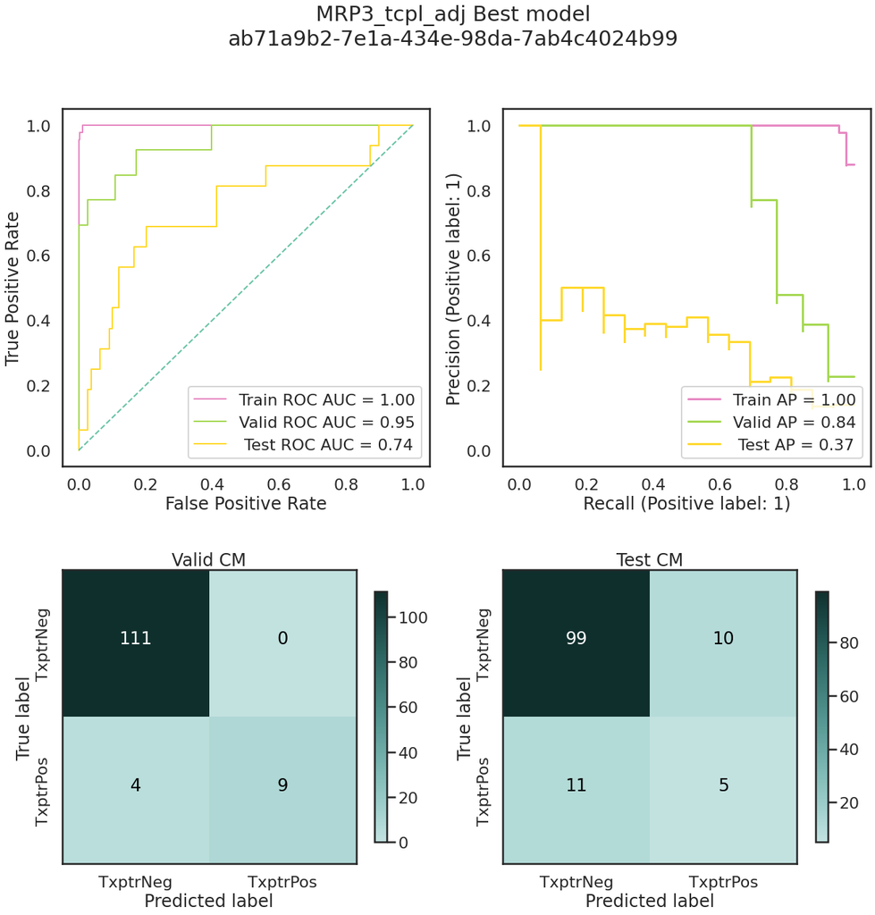

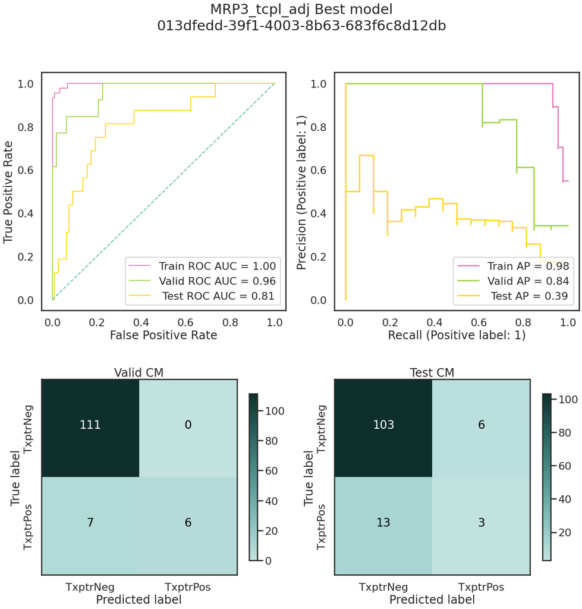

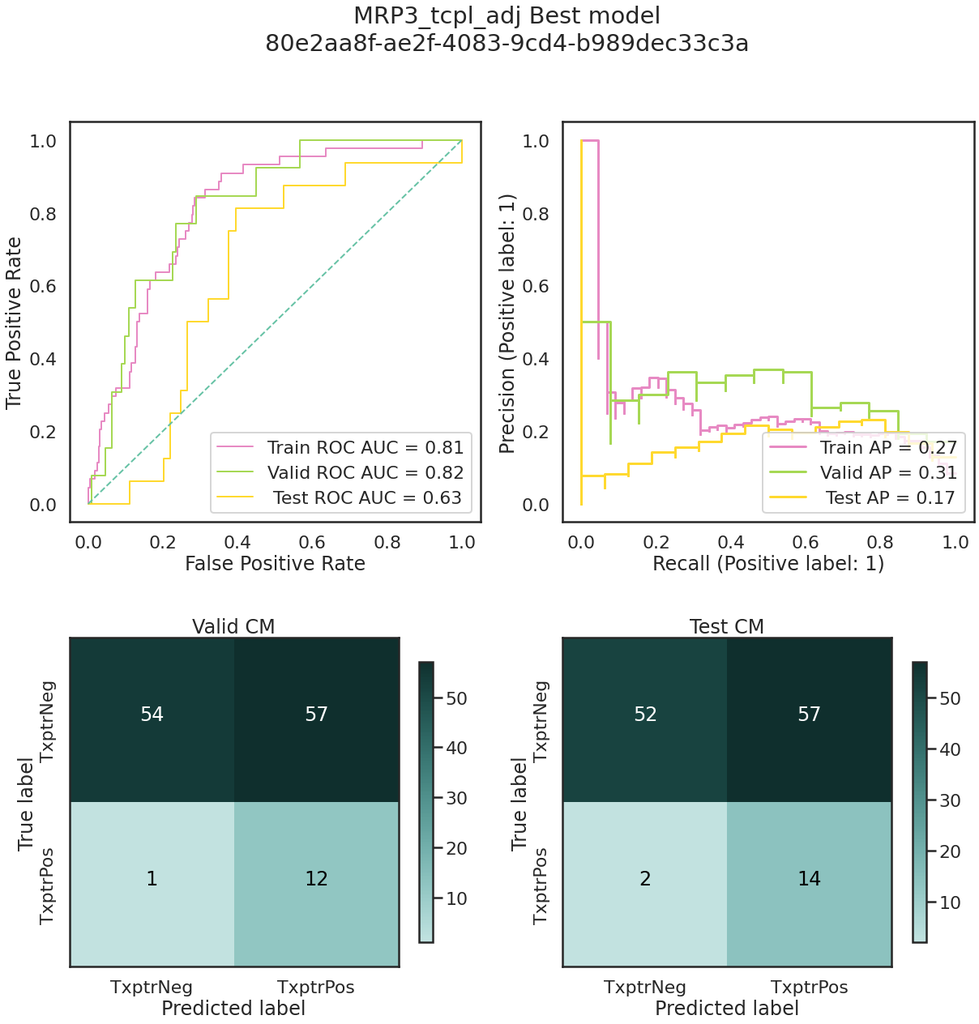

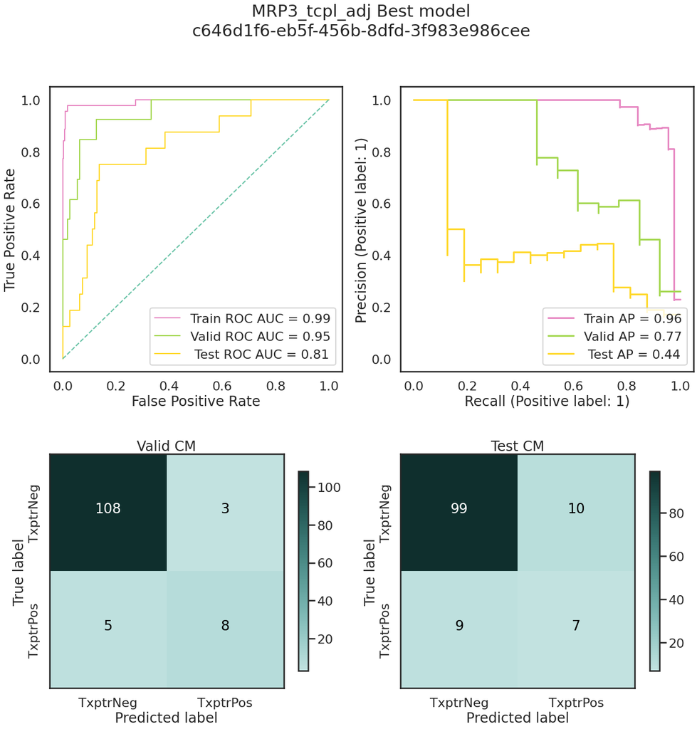

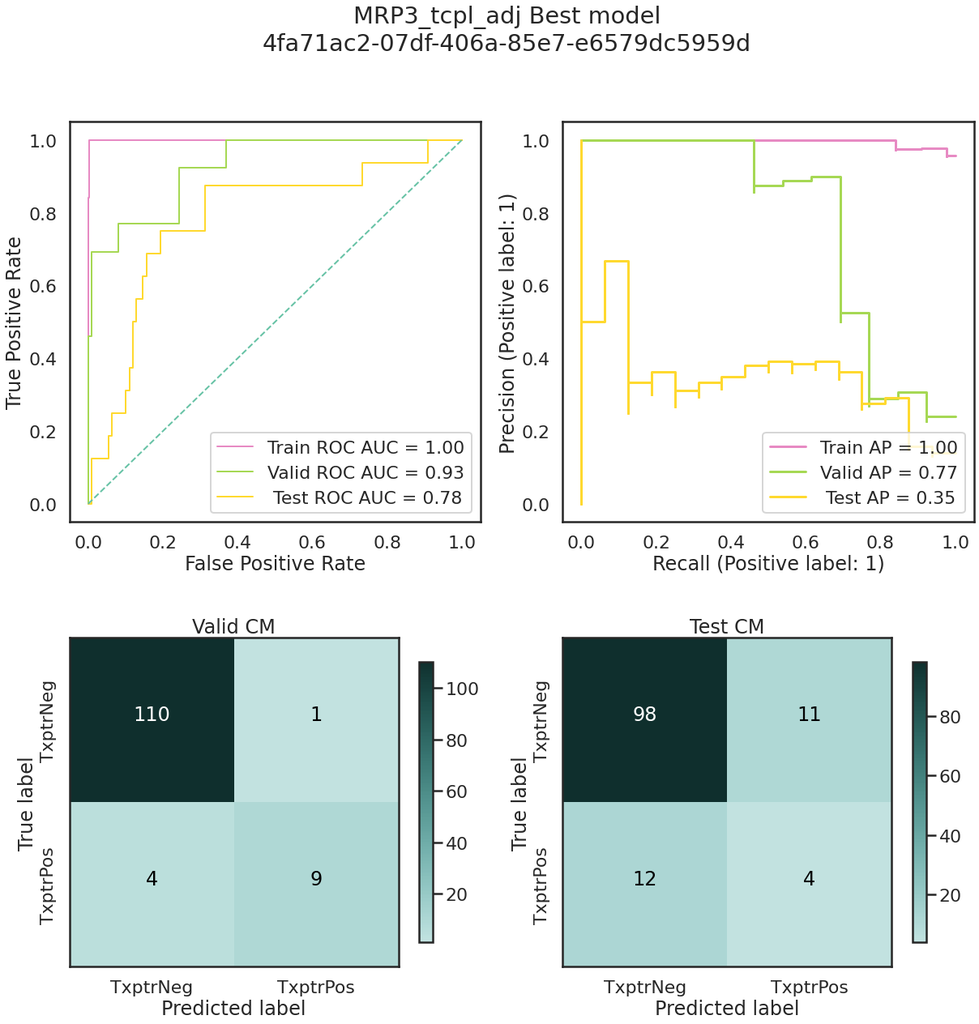

```python
sns.set_context('poster')
sns.set_style("white")
tcpl='_tcpl';adj='_adj'
id_col='compound_id'
smiles_col='base_rdkit_smiles'
pos_label=1
class_names=['TxptrNeg', 'TxptrPos']

model_label='Best model'

preds_all=[]

with warnings.catch_warnings():
    warnings.simplefilter('ignore')
    for model_uuid in top_models:
        print('\n',model_uuid)
# set variable names & get data
        collection_name = mt.get_model_collection_by_uuid(model_uuid)
        top_model=mt.get_full_metadata_by_uuid(model_uuid, collection_name)
        dataset_key=top_model['training_dataset']['dataset_key']
        dataset = dataset_key.split('/')[-1].replace('.csv','')
        df=pd.read_csv(dataset_key, index_col=0)
        response_cols = top_model['training_dataset']['response_cols']
        if len(response_cols)==1: response_col=response_cols[0]
        else: response_col=response_cols
        featurizer= top_model['model_parameters']['featurizer']
        cols=['compound_id', 'active_MRP3_tcpl_adj', 'Molecule Name_MRP3', 'active_MRP4_tcpl_adj', 'active_BSEP_tcpl_adj']
        split_uuid=top_model['splitting_parameters']['split_uuid']
        if featurizer == 'computed_descriptors':
            featurized = True
            feat_type=top_model['descriptor_specific']['descriptor_type']
            feat = pd.read_csv(f'/g/g16/apaulson/workspace/datasets/scaled_descriptors/{dataset}_with_{feat_type}_descriptors.csv')
        else:
            featurized = False
            feat_type = featurizer
            feat=df
        feat[id_col]=feat[id_col].astype(str)
        meta=df[cols]
        meta[id_col]=meta[id_col].astype(str)
        splitdf=pd.read_csv(f'/g/g16/apaulson/workspace/datasets/{dataset}_train_valid_test_scaffold_{split_uuid}.csv')
        splitdf['cmpd_id']=splitdf['cmpd_id'].astype(str)
# list model metrics from model tracker
#         print('Training metrics from model tracker\n\n', top_model['training_metrics'][0]['prediction_results'], '\n')
#         print('Validation metrics from model tracker\n\n', top_model['training_metrics'][1]['prediction_results'], '\n')
#         print('Test metrics from model tracker\n\n', top_model['training_metrics'][2]['prediction_results'], '\n')
# predict (either predict from model or this code snippet give same results)
        pred_params = {
        'featurizer': 'computed_descriptors',
        'result_dir': tempfile.mkdtemp(),
        'id_col': id_col,
        'smiles_col': smiles_col,
        'response_cols': response_cols
        }
        pred_params = parse.wrapper(pred_params)
        # pipe, pparams = mp.load_from_tracker(model_uuid)
        pipe = mp.create_prediction_pipeline(pred_params, model_uuid, collection_name)
        if pipe.params.model_type == 'xgboost':
            pipe.params.uncertainty = False
        full_df = pipe.predict_full_dataset(feat, contains_responses=True, is_featurized=featurized,
                                            dset_params=pred_params)
#         full_df = pfm.predict_from_tracker_model(model_uuid, collection_name, feat, id_col,
#                                                  smiles_col, response_cols,
#                                                  is_featurized=featurized, dont_standardize=True)
        full_df=full_df.merge(meta, how="inner", on="compound_id")
        full_df=full_df.merge(splitdf, how="inner", left_on="compound_id", right_on="cmpd_id")
        full_df=full_df[~full_df[response_col].isna()]
# graph
        fig, ax = plt.subplots(2,2, sharex=False, sharey=False, figsize=(20,20))
        ax=ax.ravel()
# training set
        pred_df=full_df[full_df.subset=='train']
    # calculate further metrics
#         print('\nCalculated metrics from predictions')
        accscore = accuracy_score(pred_df[f'{response_col}'], pred_df[f'{response_col}_pred'])
#         print('\ntrain accuracy', accscore)
        cm=confusion_matrix(pred_df[f'{response_col}'], pred_df[f'{response_col}_pred'])
#         print('train CM', cm)
        average_precision = average_precision_score(pred_df[f'{response_col}'], pred_df[f'{response_col}_prob'])
#         print('train prc_auc', average_precision)
        prescore = precision_score(pred_df[f'{response_col}'], pred_df[f'{response_col}_pred'], average='binary')
#         print("train precision", prescore)
        recscore =    recall_score(pred_df[f'{response_col}'], pred_df[f'{response_col}_pred'], average='binary')
#         print("train recall", recscore)
        roc_auc = roc_auc_score(pred_df[f'{response_col}'], pred_df[f'{response_col}_prob'])
#         print("train roc_auc", roc_auc, '\n')
    # plot curve
        fpr, tpr, _ = roc_curve(pred_df[f'{response_col}'], pred_df[f'{response_col}_prob'])
        lw = 2
        ax[0].plot(fpr, tpr, lw=lw, label='Train ROC AUC = %0.2f' % roc_auc, color = pal[3])
    # prc
        precision, recall, _ = precision_recall_curve(pred_df[f'{response_col}'], pred_df[f'{response_col}_prob'])
        line_kwargs = {"drawstyle": "steps-post"}
        line_kwargs["label"] = (f"Train AP = "
                                f"{average_precision:0.2f}")
        ax[1].plot(recall, precision, color=pal[3], **line_kwargs)
# validation set
        pred_df=full_df[full_df.subset=='valid']
    # calculate further metrics
        accscore = accuracy_score(pred_df[f'{response_col}'], pred_df[f'{response_col}_pred'])
#         print('valid accuracy', accscore)
        cm=confusion_matrix(pred_df[f'{response_col}'], pred_df[f'{response_col}_pred'])
#         print('valid CM', cm)
        average_precision = average_precision_score(pred_df[f'{response_col}'], pred_df[f'{response_col}_prob'])
#         print('valid prc_auc', average_precision)
        prescore = precision_score(pred_df[f'{response_col}'], pred_df[f'{response_col}_pred'], average='binary')
#         print("valid precision", prescore)
        recscore =    recall_score(pred_df[f'{response_col}'], pred_df[f'{response_col}_pred'], average='binary')
#         print("valid recall", recscore)
        roc_auc = roc_auc_score(pred_df[f'{response_col}'], pred_df[f'{response_col}_prob'])
#         print("valid roc_auc", roc_auc, '\n')
    # ROC AUC curve
        fpr, tpr, _ = roc_curve(pred_df[f'{response_col}'], pred_df[f'{response_col}_prob'])
        lw = 2
        line_kwargs = {"drawstyle": "steps-post"}
        ax[0].plot(fpr, tpr, lw=lw, label='Valid ROC AUC = %0.2f' % roc_auc, color = pal[4], **line_kwargs)
    # PR curve
        precision, recall, _ = precision_recall_curve(pred_df[f'{response_col}'], pred_df[f'{response_col}_prob'])
        line_kwargs = {"drawstyle": "steps-post"}
        line_kwargs["label"] = (f"Valid AP = "
                                f"{average_precision:0.2f}")
        ax[1].plot(recall, precision, color=pal[4], **line_kwargs)
    # confusion matrix - valid set (recalculated, not from table)
        cm=confusion_matrix(pred_df[f'{response_col}'], pred_df[f'{response_col}_pred'])
        im = pfma.plot_confusion_matrix(cm, classes=class_names, normalize=False, cmap=sns.cubehelix_palette(rot=0, start=2.40, as_cmap=True), ax=ax[2])
        fig.colorbar(mappable=im, ax=ax[2], shrink=0.7)
        ax[2].set_title("Valid CM")
# test set
        pred_df=full_df[full_df.subset=='test']
    # calculate further metrics
        accscore = accuracy_score(pred_df[f'{response_col}'], pred_df[f'{response_col}_pred'])
#         print('test accuracy', accscore)
        cm=confusion_matrix(pred_df[f'{response_col}'], pred_df[f'{response_col}_pred'])
#         print('test CM', cm)
        average_precision = average_precision_score(pred_df[f'{response_col}'], pred_df[f'{response_col}_prob'])
#         print('test prc_auc', average_precision)
        prescore = precision_score(pred_df[f'{response_col}'], pred_df[f'{response_col}_pred'], average='binary')
#         print("test precision", prescore)
        recscore =    recall_score(pred_df[f'{response_col}'], pred_df[f'{response_col}_pred'], average='binary')
#         print("test recall", recscore)
        roc_auc = roc_auc_score(pred_df[f'{response_col}'], pred_df[f'{response_col}_prob'])
#         print("test roc_auc", roc_auc, '\n')
    # ROC AUC curve
        fpr, tpr, _ = roc_curve(pred_df[f'{response_col}'], pred_df[f'{response_col}_prob'])
        lw = 2
        line_kwargs = {"drawstyle": "steps-post"}
        ax[0].plot(fpr, tpr, lw=lw, label=' Test ROC AUC = %0.2f' % roc_auc, color = pal[5], **line_kwargs)
        ax[0].plot([0, 1], [0, 1], lw=lw, linestyle='--')
        ax[0].set_xlim([-0.05, 1.05])
        ax[0].set_ylim([-0.05, 1.05])
        ax[0].set_xlabel('False Positive Rate')
        ax[0].set_ylabel('True Positive Rate')
        ax[0].legend(loc="lower right")
    # PR curve
        precision, recall, _ = precision_recall_curve(pred_df[f'{response_col}'], pred_df[f'{response_col}_prob'])
        line_kwargs = {"drawstyle": "steps-post"}
        line_kwargs["label"] = (f" Test AP = "
                                f"{average_precision:0.2f}")
        ax[1].plot(recall, precision, color=pal[5], **line_kwargs)
        info_pos_label = (f" (Positive label: {pos_label})")
        xlabel = "Recall" + info_pos_label
        ylabel = "Precision" + info_pos_label
        ax[1].set(xlabel=xlabel, ylabel=ylabel)
        ax[1].set_xlim([-0.05, 1.05])
        ax[1].set_ylim([-0.05, 1.05])
        ax[1].legend(loc="lower right")
    # confusion matrix - test set  (recalculated, not from table)
        cm=confusion_matrix(pred_df[f'{response_col}'], pred_df[f'{response_col}_pred'])
        im=pfma.plot_confusion_matrix(cm, classes=class_names, normalize=False, cmap=sns.cubehelix_palette(rot=0, start=2.40, as_cmap=True), ax=ax[3])
        fig.colorbar(mappable=im, ax=ax[3], shrink=0.7)
        ax[3].set_title("Test CM")
        fig.suptitle(f'{dataset} {model_label}\n{model_uuid}')

        preds_all.append((model_uuid, full_df))
```

```python
txptr='MRP3'
falses=pd.DataFrame([], columns = ['model_uuid', 'type', 'falses'])
for model_uuid, df in preds_all:
    falses = falses.append(pd.DataFrame({'model_uuid':model_uuid, 'type':-1,'falses':df[(df[f'active_{txptr}_tcpl_adj_actual'] - df[f'active_{txptr}_tcpl_adj_pred'])==1].compound_id.tolist()}))
    falses = falses.append(pd.DataFrame({'model_uuid':model_uuid, 'type':1,'falses':df[(df[f'active_{txptr}_tcpl_adj_actual'] - df[f'active_{txptr}_tcpl_adj_pred'])==-1].compound_id.tolist()}))
```

```python
falses.pivot(index='falses', columns='model_uuid', values='type')
```

| model_uuid falses | 013dfedd-39f1-4003-8b63-683f6c8d12db | 4fa71ac2-07df-406a-85e7-e6579dc5959d | 80e2aa8f-ae2f-4083-9cd4-b989dec33c3a | ab71a9b2-7e1a-434e-98da-7ab4c4024b99 | c646d1f6-eb5f-456b-8dfd-3f983e986cee |
| --- | --- | --- | --- | --- | --- |
| 000011_1 | NaN | NaN | 1 | NaN | NaN |
| 000016_1 | NaN | NaN | 1 | NaN | NaN |
| 000018_1 | NaN | NaN | 1 | NaN | NaN |
| 000019_1 | NaN | NaN | 1 | NaN | NaN |
| 000023_1 | -1 | NaN | NaN | NaN | NaN |
| ... | ... | ... | ... | ... | ... |
| 9886273 | NaN | NaN | 1 | NaN | NaN |
| 9887755 | NaN | NaN | 1 | NaN | NaN |
| 9915743 | NaN | NaN | 1 | NaN | 1 |
| 9931156 | NaN | NaN | 1 | NaN | NaN |
| 9933004 | NaN | NaN | 1 | NaN | NaN |

334 rows × 5 columns

```python
falses
```

|  | model_uuid | type | falses |
| --- | --- | --- | --- |
| 0 | ab71a9b2-7e1a-434e-98da-7ab4c4024b99 | -1 | 000053_1 |
| 1 | ab71a9b2-7e1a-434e-98da-7ab4c4024b99 | -1 | 25019940 |
| 2 | ab71a9b2-7e1a-434e-98da-7ab4c4024b99 | -1 | 92727 |
| 3 | ab71a9b2-7e1a-434e-98da-7ab4c4024b99 | -1 | 6918686 |
| 4 | ab71a9b2-7e1a-434e-98da-7ab4c4024b99 | -1 | 000131_1 |
| ... | ... | ... | ... |
| 8 | 4fa71ac2-07df-406a-85e7-e6579dc5959d | 1 | 6918155 |
| 9 | 4fa71ac2-07df-406a-85e7-e6579dc5959d | 1 | 000109_1 |
| 10 | 4fa71ac2-07df-406a-85e7-e6579dc5959d | 1 | 3000226 |
| 11 | 4fa71ac2-07df-406a-85e7-e6579dc5959d | 1 | 2662 |
| 12 | 4fa71ac2-07df-406a-85e7-e6579dc5959d | 1 | 216237 |

437 rows × 3 columns